# MDS Model - Retail Example Explained

emora034

March 2, 2020

### Multidimensional Scaling

Mulidimensional scaling (MDS) is a visual representation of distances or dissimilarities between sets of objects. “Objects” can be colors, faces, map coordinates, political persuasion, or any kind of real or conceptual stimuli (Kruskal and Wish, 1978). Its main goal is to reduce the dimensionality of the data by finding a set of points that will relatively reflect the configuration of our original high-dimensional set. This reduction usually leads to a two-dimensional set, so that we can get a 2D spatial representation of the objects.

To implement the MDS model, 11 clothing retail stores accessible in the U.S. have been selected: Forever 21, Zara, H&M, Ross, Marshall’s, T.J. Maxx, Macy’s, JC Penny, GUESS, Old Navy, and Levis. Then, an opinion of the similarities amongst the stores is defined in a scale from 0-10, 0 indicating the very least similarity and 10, the highest similarity between stores. The overall subjective opinion is found on the table below (matrix D):

|  | Forever21 | Zara | H&M | ROSS | Marshall’s | T.J. Max | Macy’s | JC Penny | GUESS | Old Navy | Levis |
| --- | --- | --- | --- | --- | --- | --- | --- | --- | --- | --- | --- |
| Forever 21 | 10 | 7 | 8 | 4 | 4 | 4 | 2 | 2 | 1 | 6 | 6 |
| Zara | 7 | 10 | 9 | 3 | 3 | 2 | 3 | 1 | 6 | 1 | 4 |
| H & M | 8 | 9 | 10 | 2 | 2 | 2 | 3 | 1 | 6 | 4 | 5 |
| ROSS | 4 | 3 | 2 | 10 | 8 | 8 | 4 | 6 | 1 | 3 | 3 |
| Marshall’s | 4 | 3 | 2 | 8 | 10 | 9 | 6 | 7 | 1 | 4 | 4 |
| T.J. Max | 4 | 2 | 2 | 8 | 9 | 10 | 5 | 4 | 1 | 3 | 4 |
| Macy’s | 2 | 3 | 3 | 4 | 6 | 5 | 10 | 8 | 7 | 4 | 2 |
| JC Penny | 2 | 1 | 1 | 6 | 7 | 4 | 8 | 10 | 0 | 6 | 5 |
| GUESS | 1 | 6 | 6 | 1 | 1 | 1 | 7 | 0 | 10 | 0 | 3 |
| Old Navy | 6 | 1 | 4 | 3 | 4 | 3 | 4 | 6 | 0 | 10 | 8 |
| Levis | 6 | 4 | 5 | 3 | 4 | 4 | 2 | 5 | 3 | 8 | 10 |

In this table we can see that GUESS is the least similar to JC Penny and Old Navy with a score of zero. While JC Penny offers a diversity of brands and products at an affordable price, the styles of the clothes are usually not at par with the latest fashion trends, nor is the quality of the clothes good. Old Navy, on the other hand, has a very set theme of casual affordable clothing and the color schemes are usually mellow. In contrast GUESS is an upscale retailer, where the clothing and accessories sold are much more expensive. The line usually has fashion forward and daring styles, with vibrant colors, and high quality.

On the other end, H & M and Zara are among the highest similarity ratings within matrix D. These two foreign retailers offer trendy items seasonally at reasonable prices. The overall quality of their products is very similar, as well as the styles, color schemes and patters, prices and even the way the stores are organized.

Given matrix D, the dissimilarity matrix can be generated. This matrix results in an n x p size, where n > p due to the repetitive nature of the information contained in the first row and last column.

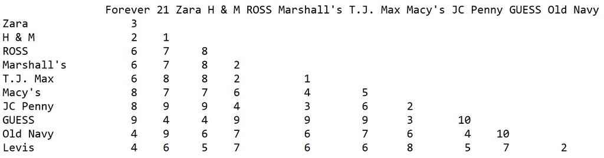

In this instance, the interpretation is different. We can now observe the distances between the store - the dissimilarities. The higher the value observed, the more dissimilar the retailers are, and vice versa. For example, holding ROSS as our base and looking in this column, it can be observed that it is the least dissimilar to Marshall’s and T.J. Maxx, which makes sense as the 3 stores sale brand name and designer clothes for a fraction of the original cost; however, it differs significantly from GUESS.

Given the matrix of dissimilarities, we may now compute its squared value in order to obtain the matrix
$$Q=-{\frac{1}2}P_nD^{(2)}P_n where P_n=I_n-{\frac{1}n}I_nI_n'$$

This computation leads to the retrieval of the eigenvalues of Q, which will help us determine which variables better explain the overall model. Retrieving the eigenvalues we get:
$$\lambda= (115.7, 70.85, 45.63, 13.27, 11.53, 2.58, 3.55e-14, -5.6, -8.56, -15.16, -26.73)$$

Only 7 eigenvalues are positive, so we may conclude that $r=7$. We now proceed to compute the 7 precision measures given by:
$$m_r=\frac{\sum_{i=1}^r\lambda_i}{\sum_{i=1}^n|{\lambda_i}|}$$

$$m_7=0.3667, 0.5911, 0.7357, 0.7777, 0.8142, 0.8224, 0.8224$$

The precision measures show the cumulative variability of the data explained by components, similar to the Principal Component Analysis method (PCA). The first two coordinates explain about 59% of the data. Plotting the two principal coordinates we get:

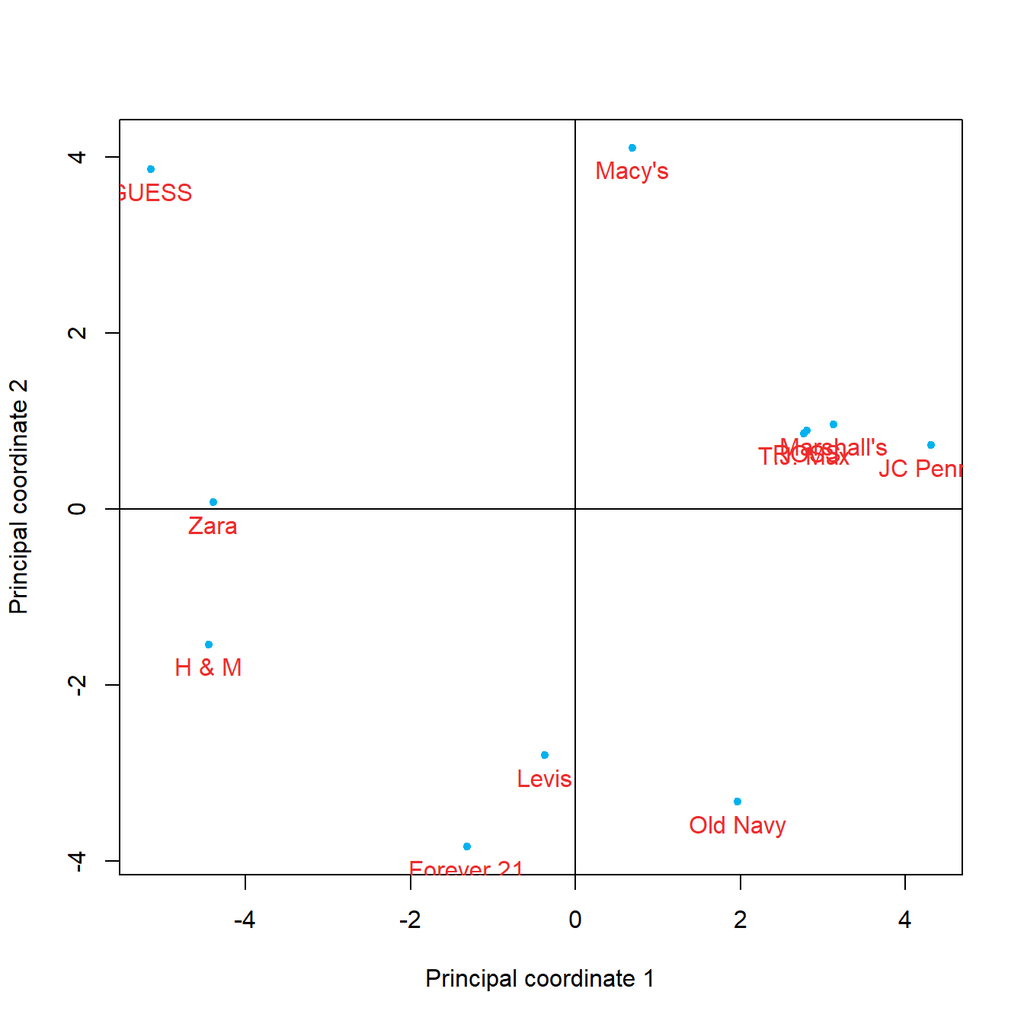